# Assignment 10

Liam

11/6/2019

```r
library(tidyverse)
library(caret)
library(rpart)
library(rattle)
titanic<-read_csv("C:\\Users\\student\\Desktop\\Fall2019\\R\\titanic.csv")
titanic<-data.frame(titanic)%>%
  rename(target = Survived) %>%
  select(-c(Name, Ticket, Cabin, PassengerId))%>%
  drop_na
titanic$target <- factor(titanic$target)
splitIndex <- createDataPartition(titanic$target, p = .70, list = FALSE)
train <- titanic[ splitIndex,]
test <- titanic[-splitIndex,]
```

The following codes implement decision tree (in rpart) and random forest (in ranger) in Caret.

```r
library(caret)

# Train Decision Tree
model <- train(target~.,data =train, method = "rpart")

# Predict using the trained tree
pred2=predict(model,test)

# Evaluate the result
confusionMatrix(pred2, test$target, positive="1")


# Train random forest
model <- train(target~.,data =train, method = "ranger")

# Predict using the trained random forest
pred2=predict(model,test)

# Evaluate the result
confusionMatrix(pred2, test$target, positive="1")
```

[output not shown]

As you observe, the codes for decision tree and random forest are the same except for the method=… The list of supported models/packages that Caret provides can be found here.

Do the follows

Compute the accuracy of Linear Discriminant Analysis model on the titanic prediction.

```r
titanic<-read_csv("C:\\Users\\student\\Desktop\\Fall2019\\R\\titanic.csv")
titanic<-data.frame(titanic)%>%
  rename(target = Survived) %>%
  select(-c(Name, Ticket, Cabin, PassengerId))%>%
  drop_na
titanic$target <- factor(titanic$target)
splitIndex <- createDataPartition(titanic$target, p = .70, list = FALSE)
train <- titanic[ splitIndex,]
test <- titanic[-splitIndex,]
model <- train(target~.,data =train, method = "lda")

# Predict using the trained tree
pred2=predict(model,test)

# Evaluate the result
confusionMatrix(pred2, test$target, positive="1")$overall["Accuracy"]
```

```
##  Accuracy
## 0.7652582
```

```r
library(rattle)
titanic<-read_csv("C:\\Users\\student\\Desktop\\Fall2019\\R\\titanic.csv")
titanic<-data.frame(titanic)%>%
  rename(target = Survived) %>%
  select(-c(Name, Ticket, Cabin, PassengerId))%>%
  drop_na
#titanic$target <- factor(titanic$target)
splitIndex <- createDataPartition(titanic$target, p = .70, list = FALSE)
train <- titanic[ splitIndex,]
test <- titanic[-splitIndex,]

modelComparisons <- function(df, #must have a binary variable named target with 1 as the positive value
                             modelVector #Must be a vector of models
) {
  dat<-data.frame()
  dmy<-dummyVars(" ~. ",df)
  df=data.frame(predict(dmy, newdata = df))
  df$target<-factor(df$target)
  splitIndex <- createDataPartition(df$target, p = .70, list = FALSE)
  train <- df[ splitIndex,]
  test <- df[-splitIndex,]
  for (z in modelVector) {
    Model <- train(target~.,data =train, method = z)
    Pred = predict(Model, test)
    data_frame <-data.frame("method"=z,
                            "accuracy"=confusionMatrix(Pred, test$target, positive="1")$overall["Accuracy"],
                            "balanced_accuracy"=confusionMatrix(Pred, test$target, positive="1")$byClass["Balanced Accuracy"])
    dat<-rbind(dat,data_frame)
  }
dat<-dat%>%
      select(c(method,accuracy,balanced_accuracy))%>%
      arrange(-accuracy)
rownames(dat)<-c()
return(dat)
}
modelComparisons(titanic, c("lda", "ranger", "rpart", "glm"))
```

[output not shown]

[output not shown]

[output cut: 22 more lines]

[output not shown]

```
##   method  accuracy balanced_accuracy
## 1 ranger 0.8075117         0.7916590
## 2  rpart 0.7793427         0.7624062
## 3    glm 0.7793427         0.7717909
## 4    lda 0.7652582         0.7543490
```

In assignment 9, we actually cheated a bit when tuning the parameters for decision tree and random forest. We did use the test set to reveal the best selections for the parameters. The test set should not be used for tuning purpose. It should only be used as the evaluation of the final model. This below codes show how caret tunes the parameters (mtry, splitrule and min.node.size) ofthe ranger random forest not using the test set.

```r
# Set the searching range
library(ranger)
titanic<-read_csv("C:\\Users\\student\\Desktop\\Fall2019\\R\\titanic.csv")
titanic<-data.frame(titanic)%>%
  rename(target = Survived) %>%
  select(-c(Name, Ticket, Cabin, PassengerId))%>%
  drop_na
titanic$target <- factor(titanic$target)
splitIndex <- createDataPartition(titanic$target, p = .70, list = FALSE)
train <- titanic[ splitIndex,]
test <- titanic[-splitIndex,]

myGrid = expand.grid(mtry = c(1:2), splitrule = c("gini"),
  min.node.size = c(1:2))

model <- train(target~.,data = train, method = "ranger", tuneGrid=myGrid)
print(model)
```

```
## Random Forest
##
## 499 samples
##   7 predictor
##   2 classes: '0', '1'
##
## No pre-processing
## Resampling: Bootstrapped (25 reps)
## Summary of sample sizes: 499, 499, 499, 499, 499, 499, ...
## Resampling results across tuning parameters:
##
##   mtry  min.node.size  Accuracy   Kappa
##   1     1              0.7883631  0.5381465
##   1     2              0.7906469  0.5432043
##   2     1              0.8158287  0.6073822
##   2     2              0.8175017  0.6110918
##
## Tuning parameter 'splitrule' was held constant at a value of gini
## Accuracy was used to select the optimal model using the largest value.
## The final values used for the model were mtry = 2, splitrule = gini
##  and min.node.size = 2.
```

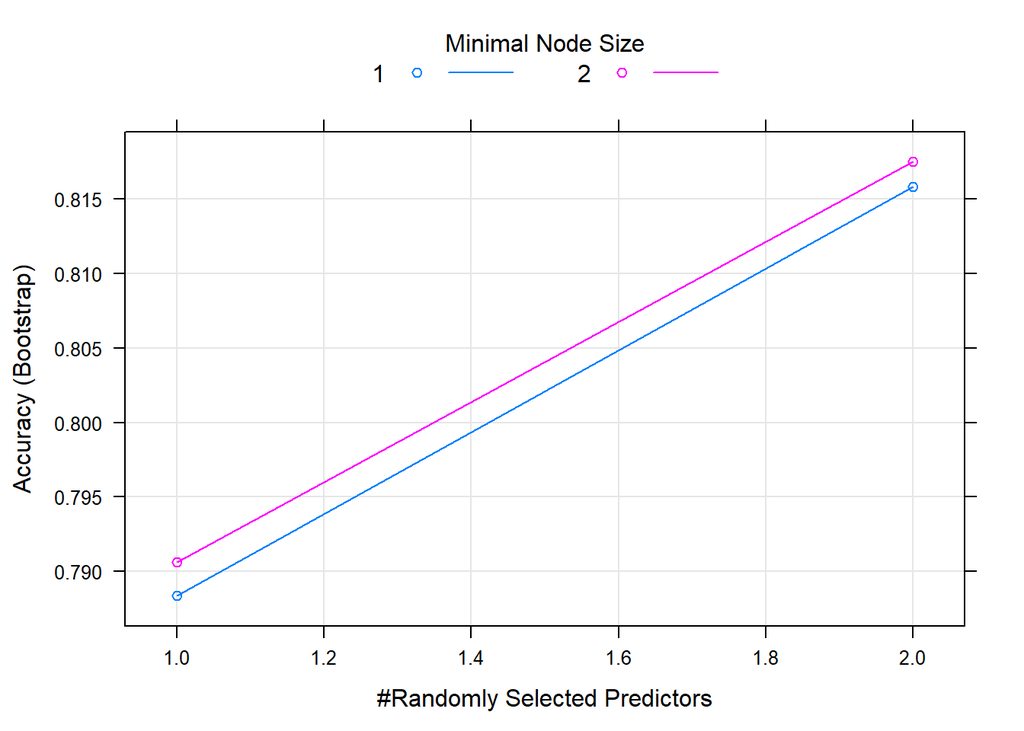

```r
# Plot the tuning result
plot(model)
```

```r
# Used the tuned model for prediction
pred  = predict(model, test)
cm=confusionMatrix(pred, test$target, positive="1")
cm
```

```
## Confusion Matrix and Statistics
##
##           Reference
## Prediction   0   1
##          0 104  28
##          1  23  58
##
##                Accuracy : 0.7606
##                  95% CI : (0.6975, 0.8162)
##     No Information Rate : 0.5962
##     P-Value [Acc > NIR] : 3.278e-07
##
##                   Kappa : 0.498
##
##  Mcnemar's Test P-Value : 0.5754
##
##             Sensitivity : 0.6744
##             Specificity : 0.8189
##          Pos Pred Value : 0.7160
##          Neg Pred Value : 0.7879
##              Prevalence : 0.4038
##          Detection Rate : 0.2723
##    Detection Prevalence : 0.3803
##       Balanced Accuracy : 0.7467
##
##        'Positive' Class : 1
##
```

Not all parameters of ranger can be tuned with caret. Caret only support to tune three parameters: mtry, splitrule and min.node.size. To see the supported tuning parameters of ranger in caret, one can use this link or use getModelInfo(‘ranger’)$ranger$parameters.

Do the follows

What is the tuning parameter of decision tree rpart2 in caret? Tune this parameter and plot the result. Report the accuracy.

```r
getModelInfo('rpart2')$rpart2$parameters
```

```
##   parameter   class          label
## 1  maxdepth numeric Max Tree Depth
```

```r
myGrid = expand.grid(maxdepth = c(1:10))

model <- train(target~.,data = train, method = "rpart2", tuneGrid=myGrid)
print(model)
```

```
## CART
##
## 499 samples
##   7 predictor
##   2 classes: '0', '1'
##
## No pre-processing
## Resampling: Bootstrapped (25 reps)
## Summary of sample sizes: 499, 499, 499, 499, 499, 499, ...
## Resampling results across tuning parameters:
##
##   maxdepth  Accuracy   Kappa
##    1        0.8136533  0.6047497
##    2        0.8053984  0.5893690
##    3        0.8045627  0.5872454
##    4        0.8069506  0.5928012
##    5        0.8031628  0.5854950
##    6        0.8015013  0.5821247
##    7        0.7982258  0.5741640
##    8        0.7979815  0.5740016
##    9        0.7975152  0.5732608
##   10        0.7977311  0.5738095
##
## Accuracy was used to select the optimal model using the largest value.
## The final value used for the model was maxdepth = 1.
```

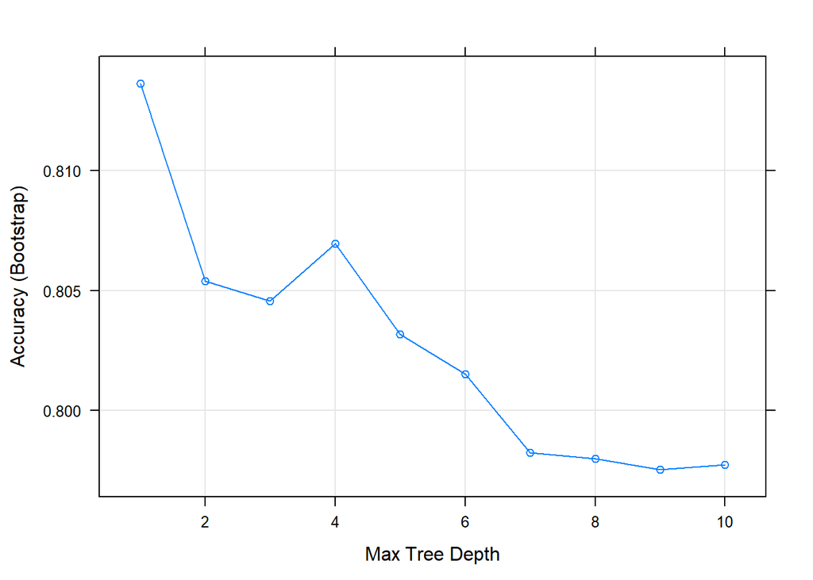

```r
# Plot the tuning result
plot(model)
```

```r
# Used the tuned model for prediction
pred  = predict(model, test)
cm=confusionMatrix(pred, test$target, positive="1")
cm
```

```
## Confusion Matrix and Statistics
##
##           Reference
## Prediction  0  1
##          0 96 33
##          1 31 53
##
##                Accuracy : 0.6995
##                  95% CI : (0.6331, 0.7603)
##     No Information Rate : 0.5962
##     P-Value [Acc > NIR] : 0.001143
##
##                   Kappa : 0.3736
##
##  Mcnemar's Test P-Value : 0.900524
##
##             Sensitivity : 0.6163
##             Specificity : 0.7559
##          Pos Pred Value : 0.6310
##          Neg Pred Value : 0.7442
##              Prevalence : 0.4038
##          Detection Rate : 0.2488
##    Detection Prevalence : 0.3944
##       Balanced Accuracy : 0.6861
##
##        'Positive' Class : 1
##
```

Train and tune two other models using caret. Plot the result. Report the accuracy.

```r
myGrid = expand.grid(dimen = c(1:5))

model <- train(target~.,data = train, method = "lda2", tuneGrid=myGrid)
print(model)
```

```
## Linear Discriminant Analysis
##
## 499 samples
##   7 predictor
##   2 classes: '0', '1'
##
## No pre-processing
## Resampling: Bootstrapped (25 reps)
## Summary of sample sizes: 499, 499, 499, 499, 499, 499, ...
## Resampling results across tuning parameters:
##
##   dimen  Accuracy   Kappa
##   1      0.8058827  0.58718
##   2      0.8058827  0.58718
##   3      0.8058827  0.58718
##   4      0.8058827  0.58718
##   5      0.8058827  0.58718
##
## Accuracy was used to select the optimal model using the largest value.
## The final value used for the model was dimen = 1.
```

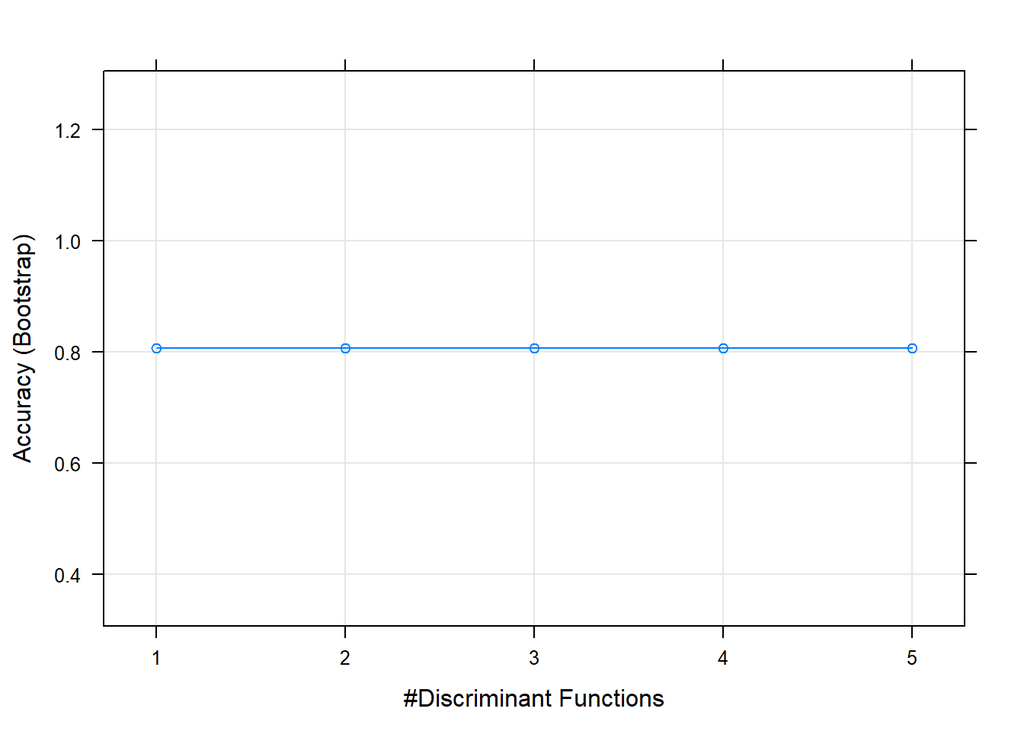

```r
# Plot the tuning result
plot(model)
```

```r
# Used the tuned model for prediction
pred  = predict(model, test)
cm=confusionMatrix(pred, test$target, positive="1")
cm
```

```
## Confusion Matrix and Statistics
##
##           Reference
## Prediction  0  1
##          0 95 29
##          1 32 57
##
##                Accuracy : 0.7136
##                  95% CI : (0.6479, 0.7733)
##     No Information Rate : 0.5962
##     P-Value [Acc > NIR] : 0.0002436
##
##                   Kappa : 0.4085
##
##  Mcnemar's Test P-Value : 0.7978939
##
##             Sensitivity : 0.6628
##             Specificity : 0.7480
##          Pos Pred Value : 0.6404
##          Neg Pred Value : 0.7661
##              Prevalence : 0.4038
##          Detection Rate : 0.2676
##    Detection Prevalence : 0.4178
##       Balanced Accuracy : 0.7054
##
##        'Positive' Class : 1
##
```

```r
titanic<-read_csv("C:\\Users\\student\\Desktop\\Fall2019\\R\\titanic.csv")
titanic<-data.frame(titanic)%>%
  rename(target = Survived) %>%
  select(-c(Name, Ticket, Cabin, PassengerId))%>%
  drop_na
titanic$target <- factor(titanic$target)
splitIndex <- createDataPartition(titanic$target, p = .70, list = FALSE)
train <- titanic[ splitIndex,]
test <- titanic[-splitIndex,]

myGrid = expand.grid(gamma = c(0.5,0.6,0.7,0.8,0.9,0.95),
                     lambda=c(0.6,0.7,0.8,0.9, 1, 1.1))

model <- train(target~.,data = train, method = "rda", tuneGrid=myGrid)
print(model)
```

```
## Regularized Discriminant Analysis
##
## 499 samples
##   7 predictor
##   2 classes: '0', '1'
##
## No pre-processing
## Resampling: Bootstrapped (25 reps)
## Summary of sample sizes: 499, 499, 499, 499, 499, 499, ...
## Resampling results across tuning parameters:
##
##   gamma  lambda  Accuracy   Kappa
##   0.50   0.6     0.6262994  0.1127874
##   0.50   0.7     0.6274004  0.1176842
##   0.50   0.8     0.6317928  0.1310240
##   0.50   0.9     0.6403857  0.1612664
##   0.50   1.0     0.6515650  0.2065089
##   0.50   1.1     0.6569728  0.2527932
##   0.60   0.6     0.6269676  0.1170053
##   0.60   0.7     0.6302462  0.1264143
##   0.60   0.8     0.6355360  0.1434239
##   0.60   0.9     0.6446533  0.1768226
##   0.60   1.0     0.6568554  0.2211782
##   0.60   1.1     0.6530410  0.2404788
##   0.70   0.6     0.6328145  0.1332253
##   0.70   0.7     0.6364050  0.1453587
##   0.70   0.8     0.6437262  0.1700757
##   0.70   0.9     0.6480140  0.1906875
##   0.70   1.0     0.6593753  0.2290421
##   0.70   1.1     0.6517841  0.2350355
##   0.80   0.6     0.6419473  0.1616393
##   0.80   0.7     0.6437261  0.1716562
##   0.80   0.8     0.6463953  0.1849795
##   0.80   0.9     0.6518191  0.2034175
##   0.80   1.0     0.6585043  0.2312606
##   0.80   1.1     0.6504064  0.2286441
##   0.90   0.6     0.6466343  0.1843125
##   0.90   0.7     0.6471128  0.1883917
##   0.90   0.8     0.6519824  0.2031905
##   0.90   0.9     0.6597075  0.2272652
##   0.90   1.0     0.6616479  0.2408630
##   0.90   1.1     0.6534447  0.2312865
##   0.95   0.6     0.6473102  0.1900878
##   0.95   0.7     0.6515014  0.2016426
##   0.95   0.8     0.6574174  0.2184479
##   0.95   0.9     0.6626999  0.2370752
##   0.95   1.0     0.6623081  0.2427111
##   0.95   1.1     0.6537283  0.2302912
##
## Accuracy was used to select the optimal model using the largest value.
## The final values used for the model were gamma = 0.95 and lambda = 0.9.
```

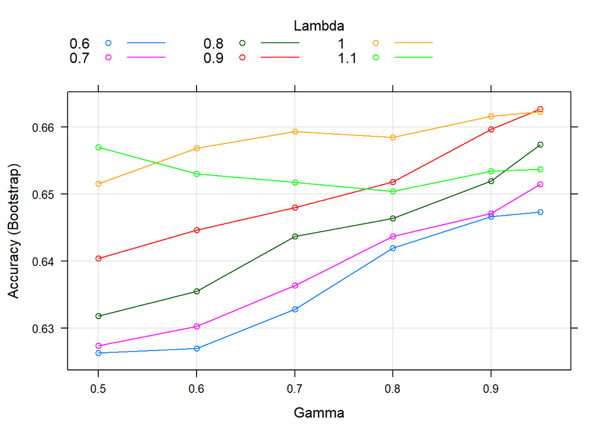

```r
# Plot the tuning result
plot(model)
```

```r
# Used the tuned model for prediction
pred  = predict(model, test)
cm=confusionMatrix(pred, test$target, positive="1")
cm
```

```
## Confusion Matrix and Statistics
##
##           Reference
## Prediction   0   1
##          0 116  58
##          1  11  28
##
##                Accuracy : 0.6761
##                  95% CI : (0.6087, 0.7384)
##     No Information Rate : 0.5962
##     P-Value [Acc > NIR] : 0.009948
##
##                   Kappa : 0.2621
##
##  Mcnemar's Test P-Value : 3.064e-08
##
##             Sensitivity : 0.3256
##             Specificity : 0.9134
##          Pos Pred Value : 0.7179
##          Neg Pred Value : 0.6667
##              Prevalence : 0.4038
##          Detection Rate : 0.1315
##    Detection Prevalence : 0.1831
##       Balanced Accuracy : 0.6195
##
##        'Positive' Class : 1
##
```